# skimage.transform

#### Notes

- The input image is converted to a `double` image.
- In case of a `SimilarityTransform`, `AffineTransform` and `ProjectiveTransform` and `order` in [0, 3] this function uses the underlying transformation matrix to warp the image with a much faster routine.

#### Examples

```
>>> from skimage.transform import warp
>>> from skimage import data
>>> image = data.camera()
```

The following image warps are all equal but differ substantially in execution time. The image is shifted to the bottom.

Use a geometric transform to warp an image (fast):

```
>>> from skimage.transform import SimilarityTransform
>>> tform = SimilarityTransform(translation=(0, -10))
>>> warped = warp(image, tform)
```

Use a callable (slow):

```
>>> def shift_down(xy):
...     xy[:, 1] -= 10
...     return xy
>>> warped = warp(image, shift_down)
```

Use a transformation matrix to warp an image (fast):

```
>>> matrix = np.array([[1, 0, 0], [0, 1, -10], [0, 0, 1]])
>>> warped = warp(image, matrix)
>>> from skimage.transform import ProjectiveTransform
>>> warped = warp(image, ProjectiveTransform(matrix=matrix))
```

You can also use the inverse of a geometric transformation (fast):

```
>>> warped = warp(image, tform.inverse)
```

For N-D images you can pass a coordinate array, that specifies the coordinates in the input image for every element in the output image. E.g. if you want to rescale a 3-D cube, you can do:

```
>>> cube_shape = np.array([30, 30, 30])
>>> rng = np.random.default_rng()
>>> cube = rng.random(cube_shape)
```

Setup the coordinate array, that defines the scaling:

```
>>> scale = 0.1
>>> output_shape = (scale * cube_shape).astype(int)
>>> coords0, coords1, coords2 = np.mgrid[:output_shape[0],
...                    :output_shape[1], :output_shape[2]]
>>> coords = np.array([coords0, coords1, coords2])
```

Assume that the cube contains spatial data, where the first array element center is at coordinate (0.5, 0.5, 0.5) in real space, i.e. we have to account for this extra offset when scaling the image:

```
>>> coords = (coords + 0.5) / scale - 0.5
>>> warped = warp(cube, coords)
```

[figure not shown]

[Piecewise Affine Transformation](https://scikit-image.org/docs/0.25.x/auto_examples/transform/plot_piecewise_affine.html#sphx-glr-auto-examples-transform-plot-piecewise-affine-py)

Piecewise Affine Transformation

[Using geometric transformations](https://scikit-image.org/docs/0.25.x/auto_examples/transform/plot_geometric.html#sphx-glr-auto-examples-transform-plot-geometric-py)

Using geometric transformations

[Types of homographies](https://scikit-image.org/docs/0.25.x/auto_examples/transform/plot_transform_types.html#sphx-glr-auto-examples-transform-plot-transform-types-py)

Types of homographies

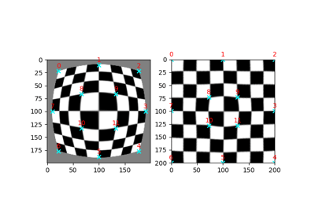

[Use thin-plate splines for image warping](https://scikit-image.org/docs/0.25.x/auto_examples/transform/plot_tps_deformation.html#sphx-glr-auto-examples-transform-plot-tps-deformation-py)

Use thin-plate splines for image warping

[Robust matching using RANSAC](https://scikit-image.org/docs/0.25.x/auto_examples/transform/plot_matching.html#sphx-glr-auto-examples-transform-plot-matching-py)

Robust matching using RANSAC

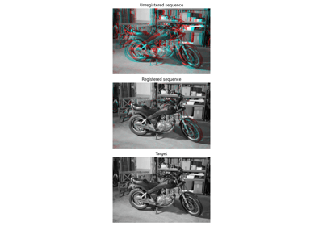

[Registration using optical flow](https://scikit-image.org/docs/0.25.x/auto_examples/registration/plot_opticalflow.html#sphx-glr-auto-examples-registration-plot-opticalflow-py)

Registration using optical flow

[Assemble images with simple image stitching](https://scikit-image.org/docs/0.25.x/auto_examples/registration/plot_stitching.html#sphx-glr-auto-examples-registration-plot-stitching-py)

Assemble images with simple image stitching

[Corner detection](https://scikit-image.org/docs/0.25.x/auto_examples/features_detection/plot_corner.html#sphx-glr-auto-examples-features-detection-plot-corner-py)

Corner detection

[CENSURE feature detector](https://scikit-image.org/docs/0.25.x/auto_examples/features_detection/plot_censure.html#sphx-glr-auto-examples-features-detection-plot-censure-py)

CENSURE feature detector

[ORB feature detector and binary descriptor](https://scikit-image.org/docs/0.25.x/auto_examples/features_detection/plot_orb.html#sphx-glr-auto-examples-features-detection-plot-orb-py)

ORB feature detector and binary descriptor

[BRIEF binary descriptor](https://scikit-image.org/docs/0.25.x/auto_examples/features_detection/plot_brief.html#sphx-glr-auto-examples-features-detection-plot-brief-py)

BRIEF binary descriptor

[figure not shown]

[SIFT feature detector and descriptor extractor](https://scikit-image.org/docs/0.25.x/auto_examples/features_detection/plot_sift.html#sphx-glr-auto-examples-features-detection-plot-sift-py)

SIFT feature detector and descriptor extractor

**`skimage.transform.warp_coords(coord_map, shape, dtype=<class 'numpy.float64'>)` [[source]](https://github.com/scikit-image/scikit-image/blob/v0.25.0/skimage/transform/_warps.py#L627-L702)**

Build the source coordinates for the output of a 2-D image warp.

**Parameters:**

**`coord_mapcallable like GeometricTransform.inverse`**

Return input coordinates for given output coordinates. Coordinates are in the shape (P, 2), where P is the number of coordinates and each element is a `(row, col)` pair.

**`shapetuple`**

Shape of output image `(rows, cols[, bands])`.

**`dtypenp.dtype or string`**

dtype for return value (sane choices: float32 or float64).

**Returns:**

**`coords(ndim, rows, cols[, bands]) array of dtype dtype`**

Coordinates for [`scipy.ndimage.map_coordinates`](https://docs.scipy.org/doc/scipy/reference/generated/scipy.ndimage.map_coordinates.html#scipy.ndimage.map_coordinates), that will yield an image of shape (orows, ocols, bands) by drawing from source points according to the `coord_transform_fn`.

#### Notes

This is a lower-level routine that produces the source coordinates for 2-D images used by `warp()`.

It is provided separately from `warp` to give additional flexibility to users who would like, for example, to re-use a particular coordinate mapping, to use specific dtypes at various points along the the image-warping process, or to implement different post-processing logic than `warp` performs after the call to `ndi.map_coordinates`.

#### Examples

```
>>> from skimage import data
>>> from scipy.ndimage import map_coordinates
>>>
>>> def shift_up10_left20(xy):
...     return xy - np.array([-20, 10])[None, :]
>>>
>>> image = data.astronaut().astype(np.float32)
>>> coords = warp_coords(shift_up10_left20, image.shape)
>>> warped_image = map_coordinates(image, coords)
```

**`skimage.transform.warp_polar(image, center=None, *, radius=None, output_shape=None, scaling='linear', channel_axis=None, **kwargs)` [[source]](https://github.com/scikit-image/scikit-image/blob/v0.25.0/skimage/transform/_warps.py#L1107-L1219)**

Remap image to polar or log-polar coordinates space.

**Parameters:**

**`image(M, N[, C]) ndarray`**

Input image. For multichannel images `channel_axis` has to be specified.

**`center2-tuple, optional`**

`(row, col)` coordinates of the point in `image` that represents the center of the transformation (i.e., the origin in Cartesian space). Values can be of type [`float`](https://docs.python.org/3/library/functions.html#float). If no value is given, the center is assumed to be the center point of `image`.

**`radiusfloat, optional`**

Radius of the circle that bounds the area to be transformed.

**`output_shapetuple (row, col), optional`**

**`scaling{‘linear’, ‘log’}, optional`**

Specify whether the image warp is polar or log-polar. Defaults to ‘linear’.

**`channel_axisint or None, optional`**

If None, the image is assumed to be a grayscale (single channel) image. Otherwise, this parameter indicates which axis of the array corresponds to channels.

Added in version 0.19: `channel_axis` was added in 0.19.

**`**kwargskeyword arguments`**

Passed to `transform.warp`.

**Returns:**

**`warpedndarray`**

The polar or log-polar warped image.

#### Examples

Perform a basic polar warp on a grayscale image:

```
>>> from skimage import data
>>> from skimage.transform import warp_polar
>>> image = data.checkerboard()
>>> warped = warp_polar(image)
```

Perform a log-polar warp on a grayscale image:

```
>>> warped = warp_polar(image, scaling='log')
```

Perform a log-polar warp on a grayscale image while specifying center, radius, and output shape:

```
>>> warped = warp_polar(image, (100,100), radius=100,
...                     output_shape=image.shape, scaling='log')
```

Perform a log-polar warp on a color image:

```
>>> image = data.astronaut()
>>> warped = warp_polar(image, scaling='log', channel_axis=-1)
```

[Using Polar and Log-Polar Transformations for Registration](https://scikit-image.org/docs/0.25.x/auto_examples/registration/plot_register_rotation.html#sphx-glr-auto-examples-registration-plot-register-rotation-py)

Using Polar and Log-Polar Transformations for Registration

**`class skimage.transform.AffineTransform(matrix=None, scale=None, rotation=None, shear=None, translation=None, *, dimensionality=2)` [[source]](https://github.com/scikit-image/scikit-image/blob/v0.25.0/skimage/transform/_geometric.py#L880-L1080)**

Bases: `ProjectiveTransform`

Affine transformation.

Has the following form:

```
X = a0 * x + a1 * y + a2
  =   sx * x * [cos(rotation) + tan(shear_y) * sin(rotation)]
    - sy * y * [tan(shear_x) * cos(rotation) + sin(rotation)]
    + translation_x

Y = b0 * x + b1 * y + b2
  =   sx * x * [sin(rotation) - tan(shear_y) * cos(rotation)]
    - sy * y * [tan(shear_x) * sin(rotation) - cos(rotation)]
    + translation_y
```

where `sx` and `sy` are scale factors in the x and y directions.

This is equivalent to applying the operations in the following order:

1. Scale
2. Shear
3. Rotate
4. Translate

The homogeneous transformation matrix is:

```
[[a0  a1  a2]
 [b0  b1  b2]
 [0   0    1]]
```

In 2D, the transformation parameters can be given as the homogeneous transformation matrix, above, or as the implicit parameters, scale, rotation, shear, and translation in x (a2) and y (b2). For 3D and higher, only the matrix form is allowed.

In narrower transforms, such as the Euclidean (only rotation and translation) or Similarity (rotation, translation, and a global scale factor) transforms, it is possible to specify 3D transforms using implicit parameters also.

**Parameters:**

**`matrix(D+1, D+1) array_like, optional`**

Homogeneous transformation matrix. If this matrix is provided, it is an error to provide any of scale, rotation, shear, or translation.

**`scale{s as float or (sx, sy) as array, list or tuple}, optional`**

Scale factor(s). If a single value, it will be assigned to both sx and sy. Only available for 2D.

Added in version 0.17: Added support for supplying a single scalar value.

**`rotationfloat, optional`**

Rotation angle, clockwise, as radians. Only available for 2D.

**`shearfloat or 2-tuple of float, optional`**

The x and y shear angles, clockwise, by which these axes are rotated around the origin [2]. If a single value is given, take that to be the x shear angle, with the y angle remaining 0. Only available in 2D.

**`translation(tx, ty) as array, list or tuple, optional`**

Translation parameters. Only available for 2D.

**`dimensionalityint, optional`**

The dimensionality of the transform. This is not used if any other parameters are provided.

**Attributes:**

**`params(D+1, D+1) array`**

Homogeneous transformation matrix.

**Raises:**

**ValueError**

If both `matrix` and any of the other parameters are provided.

#### References

[1]

Wikipedia, “Affine transformation”, https://en.wikipedia.org/wiki/Affine_transformation#Image_transformation

[2]

Wikipedia, “Shear mapping”, https://en.wikipedia.org/wiki/Shear_mapping

#### Examples

```
>>> import numpy as np
>>> import skimage as ski
>>> img = ski.data.astronaut()
```

Define source and destination points:

```
>>> src = np.array([[150, 150],
...                 [250, 100],
...                 [150, 200]])
>>> dst = np.array([[200, 200],
...                 [300, 150],
...                 [150, 400]])
```

Estimate the transformation matrix:

```
>>> tform = ski.transform.AffineTransform()
>>> tform.estimate(src, dst)
True
```

Apply the transformation:

```
>>> warped = ski.transform.warp(img, inverse_map=tform.inverse)
```

**`__init__(matrix=None, scale=None, rotation=None, shear=None, translation=None, *, dimensionality=2)` [[source]](https://github.com/scikit-image/scikit-image/blob/v0.25.0/skimage/transform/_geometric.py#L987-L1050)**

[Types of homographies](https://scikit-image.org/docs/0.25.x/auto_examples/transform/plot_transform_types.html#sphx-glr-auto-examples-transform-plot-transform-types-py)

Types of homographies

[Robust matching using RANSAC](https://scikit-image.org/docs/0.25.x/auto_examples/transform/plot_matching.html#sphx-glr-auto-examples-transform-plot-matching-py)

Robust matching using RANSAC

[Corner detection](https://scikit-image.org/docs/0.25.x/auto_examples/features_detection/plot_corner.html#sphx-glr-auto-examples-features-detection-plot-corner-py)

Corner detection

[CENSURE feature detector](https://scikit-image.org/docs/0.25.x/auto_examples/features_detection/plot_censure.html#sphx-glr-auto-examples-features-detection-plot-censure-py)

CENSURE feature detector

[ORB feature detector and binary descriptor](https://scikit-image.org/docs/0.25.x/auto_examples/features_detection/plot_orb.html#sphx-glr-auto-examples-features-detection-plot-orb-py)

ORB feature detector and binary descriptor

[BRIEF binary descriptor](https://scikit-image.org/docs/0.25.x/auto_examples/features_detection/plot_brief.html#sphx-glr-auto-examples-features-detection-plot-brief-py)

BRIEF binary descriptor

[figure not shown]

[SIFT feature detector and descriptor extractor](https://scikit-image.org/docs/0.25.x/auto_examples/features_detection/plot_sift.html#sphx-glr-auto-examples-features-detection-plot-sift-py)

SIFT feature detector and descriptor extractor

**`property dimensionality`**

The dimensionality of the transformation.

**`estimate(src, dst, weights=None)` [[source]](https://github.com/scikit-image/scikit-image/blob/v0.25.0/skimage/transform/_geometric.py#L717-L839)**

Estimate the transformation from a set of corresponding points.

You can determine the over-, well- and under-determined parameters with the total least-squares method.

Number of source and destination coordinates must match.

The transformation is defined as:

```
X = (a0*x + a1*y + a2) / (c0*x + c1*y + 1)
Y = (b0*x + b1*y + b2) / (c0*x + c1*y + 1)
```

These equations can be transformed to the following form:

```
0 = a0*x + a1*y + a2 - c0*x*X - c1*y*X - X
0 = b0*x + b1*y + b2 - c0*x*Y - c1*y*Y - Y
```

which exist for each set of corresponding points, so we have a set of N * 2 equations. The coefficients appear linearly so we can write A x = 0, where:

```
A   = [[x y 1 0 0 0 -x*X -y*X -X]
       [0 0 0 x y 1 -x*Y -y*Y -Y]
        ...
        ...
      ]
x.T = [a0 a1 a2 b0 b1 b2 c0 c1 c3]
```

In case of total least-squares the solution of this homogeneous system of equations is the right singular vector of A which corresponds to the smallest singular value normed by the coefficient c3.

Weights can be applied to each pair of corresponding points to indicate, particularly in an overdetermined system, if point pairs have higher or lower confidence or uncertainties associated with them. From the matrix treatment of least squares problems, these weight values are normalised, square-rooted, then built into a diagonal matrix, by which A is multiplied.

In case of the affine transformation the coefficients c0 and c1 are 0. Thus the system of equations is:

```
A   = [[x y 1 0 0 0 -X]
       [0 0 0 x y 1 -Y]
        ...
        ...
      ]
x.T = [a0 a1 a2 b0 b1 b2 c3]
```

**Parameters:**

**`src(N, 2) array_like`**

Source coordinates.

**`dst(N, 2) array_like`**

Destination coordinates.

**`weights(N,) array_like, optional`**

Relative weight values for each pair of points.

**Returns:**

**`successbool`**

True, if model estimation succeeds.

**`property inverse`**

Return a transform object representing the inverse.

**`residuals(src, dst)` [[source]](https://github.com/scikit-image/scikit-image/blob/v0.25.0/skimage/transform/_geometric.py#L206-L225)**

Determine residuals of transformed destination coordinates.

For each transformed source coordinate the Euclidean distance to the respective destination coordinate is determined.

**Parameters:**

**`src(N, 2) array`**

Source coordinates.

**`dst(N, 2) array`**

Destination coordinates.

**Returns:**

**`residuals(N,) array`**

Residual for coordinate.

**`property rotation`**

**`property scale`**

**`property shear`**

**`property translation`**

**`class skimage.transform.EssentialMatrixTransform(rotation=None, translation=None, matrix=None, *, dimensionality=2)` [[source]](https://github.com/scikit-image/scikit-image/blob/v0.25.0/skimage/transform/_geometric.py#L471-L615)**

Bases: `FundamentalMatrixTransform`

Essential matrix transformation.

The essential matrix relates corresponding points between a pair of calibrated images. The matrix transforms normalized, homogeneous image points in one image to epipolar lines in the other image.

The essential matrix is only defined for a pair of moving images capturing a non-planar scene. In the case of pure rotation or planar scenes, the homography describes the geometric relation between two images (`ProjectiveTransform`). If the intrinsic calibration of the images is unknown, the fundamental matrix describes the projective relation between the two images (`FundamentalMatrixTransform`).

**Parameters:**

**`rotation(3, 3) array_like, optional`**

Rotation matrix of the relative camera motion.

**`translation(3, 1) array_like, optional`**

Translation vector of the relative camera motion. The vector must have unit length.

**`matrix(3, 3) array_like, optional`**

Essential matrix.

**Attributes:**

**`params(3, 3) array`**

Essential matrix.

#### References

[1]

Hartley, Richard, and Andrew Zisserman. Multiple view geometry in computer vision. Cambridge university press, 2003.

#### Examples

```
>>> import numpy as np
>>> import skimage as ski
>>>
>>> tform_matrix = ski.transform.EssentialMatrixTransform(
...     rotation=np.eye(3), translation=np.array([0, 0, 1])
... )
>>> tform_matrix.params
array([[ 0., -1.,  0.],
       [ 1.,  0.,  0.],
       [ 0.,  0.,  0.]])
>>> src = np.array([[ 1.839035, 1.924743],
...                 [ 0.543582, 0.375221],
...                 [ 0.47324 , 0.142522],
...                 [ 0.96491 , 0.598376],
...                 [ 0.102388, 0.140092],
...                 [15.994343, 9.622164],
...                 [ 0.285901, 0.430055],
...                 [ 0.09115 , 0.254594]])
>>> dst = np.array([[1.002114, 1.129644],
...                 [1.521742, 1.846002],
...                 [1.084332, 0.275134],
...                 [0.293328, 0.588992],
...                 [0.839509, 0.08729 ],
...                 [1.779735, 1.116857],
...                 [0.878616, 0.602447],
...                 [0.642616, 1.028681]])
>>> tform_matrix.estimate(src, dst)
True
>>> tform_matrix.residuals(src, dst)
array([0.42455187, 0.01460448, 0.13847034, 0.12140951, 0.27759346,
       0.32453118, 0.00210776, 0.26512283])
```

**`__init__(rotation=None, translation=None, matrix=None, *, dimensionality=2)` [[source]](https://github.com/scikit-image/scikit-image/blob/v0.25.0/skimage/transform/_geometric.py#L541-L580)**

**`estimate(src, dst)` [[source]](https://github.com/scikit-image/scikit-image/blob/v0.25.0/skimage/transform/_geometric.py#L582-L615)**

Estimate essential matrix using 8-point algorithm.

The 8-point algorithm requires at least 8 corresponding point pairs for a well-conditioned solution, otherwise the over-determined solution is estimated.

**Parameters:**

**`src(N, 2) array_like`**

Source coordinates.

**`dst(N, 2) array_like`**

Destination coordinates.

**Returns:**

**`successbool`**

True, if model estimation succeeds.

**`property inverse`**

Return a transform object representing the inverse.

See Hartley & Zisserman, Ch. 8: Epipolar Geometry and the Fundamental Matrix, for an explanation of why F.T gives the inverse.

**`residuals(src, dst)` [[source]](https://github.com/scikit-image/scikit-image/blob/v0.25.0/skimage/transform/_geometric.py#L440-L468)**

Compute the Sampson distance.

The Sampson distance is the first approximation to the geometric error.

**Parameters:**

**`src(N, 2) array`**

Source coordinates.

**`dst(N, 2) array`**

Destination coordinates.

**Returns:**

**`residuals(N,) array`**

Sampson distance.

**`class skimage.transform.EuclideanTransform(matrix=None, rotation=None, translation=None, *, dimensionality=2)` [[source]](https://github.com/scikit-image/scikit-image/blob/v0.25.0/skimage/transform/_geometric.py#L1219-L1366)**

Bases: `ProjectiveTransform`

Euclidean transformation, also known as a rigid transform.

Has the following form:

```
X = a0 * x - b0 * y + a1 =
  = x * cos(rotation) - y * sin(rotation) + a1

Y = b0 * x + a0 * y + b1 =
  = x * sin(rotation) + y * cos(rotation) + b1
```

where the homogeneous transformation matrix is:

```
[[a0 -b0  a1]
 [b0  a0  b1]
 [0   0   1 ]]
```

The Euclidean transformation is a rigid transformation with rotation and translation parameters. The similarity transformation extends the Euclidean transformation with a single scaling factor.

In 2D and 3D, the transformation parameters may be provided either via `matrix`, the homogeneous transformation matrix, above, or via the implicit parameters `rotation` and/or `translation` (where `a1` is the translation along `x`, `b1` along `y`, etc.). Beyond 3D, if the transformation is only a translation, you may use the implicit parameter `translation`; otherwise, you must use `matrix`.

**Parameters:**

**`matrix(D+1, D+1) array_like, optional`**

Homogeneous transformation matrix.

**`rotationfloat or sequence of float, optional`**

Rotation angle, clockwise, as radians. If given as a vector, it is interpreted as Euler rotation angles [1]. Only 2D (single rotation) and 3D (Euler rotations) values are supported. For higher dimensions, you must provide or estimate the transformation matrix.

**`translation(x, y[, z, …]) sequence of float, length D, optional`**

Translation parameters for each axis.

**`dimensionalityint, optional`**

The dimensionality of the transform.

**Attributes:**

**`params(D+1, D+1) array`**

Homogeneous transformation matrix.

#### References

[]

https://en.wikipedia.org/wiki/Rotation_matrix#In_three_dimensions

**`__init__(matrix=None, rotation=None, translation=None, *, dimensionality=2)` [[source]](https://github.com/scikit-image/scikit-image/blob/v0.25.0/skimage/transform/_geometric.py#L1272-L1324)**

[Using geometric transformations](https://scikit-image.org/docs/0.25.x/auto_examples/transform/plot_geometric.html#sphx-glr-auto-examples-transform-plot-geometric-py)

Using geometric transformations

[Types of homographies](https://scikit-image.org/docs/0.25.x/auto_examples/transform/plot_transform_types.html#sphx-glr-auto-examples-transform-plot-transform-types-py)

Types of homographies

[Assemble images with simple image stitching](https://scikit-image.org/docs/0.25.x/auto_examples/registration/plot_stitching.html#sphx-glr-auto-examples-registration-plot-stitching-py)

Assemble images with simple image stitching

**`property dimensionality`**

The dimensionality of the transformation.

**`estimate(src, dst)` [[source]](https://github.com/scikit-image/scikit-image/blob/v0.25.0/skimage/transform/_geometric.py#L1326-L1350)**

Estimate the transformation from a set of corresponding points.

You can determine the over-, well- and under-determined parameters with the total least-squares method.

Number of source and destination coordinates must match.

**Parameters:**

**`src(N, 2) array_like`**

Source coordinates.

**`dst(N, 2) array_like`**

Destination coordinates.

**Returns:**

**`successbool`**

True, if model estimation succeeds.

**`property inverse`**

Return a transform object representing the inverse.

**`residuals(src, dst)` [[source]](https://github.com/scikit-image/scikit-image/blob/v0.25.0/skimage/transform/_geometric.py#L206-L225)**

Determine residuals of transformed destination coordinates.

For each transformed source coordinate the Euclidean distance to the respective destination coordinate is determined.

**Parameters:**

**`src(N, 2) array`**

Source coordinates.

**`dst(N, 2) array`**

Destination coordinates.

**Returns:**

**`residuals(N,) array`**

Residual for coordinate.

**`property rotation`**

**`property translation`**

**`class skimage.transform.FundamentalMatrixTransform(matrix=None, *, dimensionality=2)` [[source]](https://github.com/scikit-image/scikit-image/blob/v0.25.0/skimage/transform/_geometric.py#L228-L468)**

Bases: `_GeometricTransform`

Fundamental matrix transformation.

The fundamental matrix relates corresponding points between a pair of uncalibrated images. The matrix transforms homogeneous image points in one image to epipolar lines in the other image.

The fundamental matrix is only defined for a pair of moving images. In the case of pure rotation or planar scenes, the homography describes the geometric relation between two images (`ProjectiveTransform`). If the intrinsic calibration of the images is known, the essential matrix describes the metric relation between the two images (`EssentialMatrixTransform`).

**Parameters:**

**`matrix(3, 3) array_like, optional`**

Fundamental matrix.

**Attributes:**

**`params(3, 3) array`**

Fundamental matrix.

#### References

[1]

Hartley, Richard, and Andrew Zisserman. Multiple view geometry in computer vision. Cambridge university press, 2003.

#### Examples

```
>>> import numpy as np
>>> import skimage as ski
>>> tform_matrix = ski.transform.FundamentalMatrixTransform()
```

Define source and destination points:

```
>>> src = np.array([1.839035, 1.924743,
...                 0.543582, 0.375221,
...                 0.473240, 0.142522,
...                 0.964910, 0.598376,
...                 0.102388, 0.140092,
...                15.994343, 9.622164,
...                 0.285901, 0.430055,
...                 0.091150, 0.254594]).reshape(-1, 2)
>>> dst = np.array([1.002114, 1.129644,
...                 1.521742, 1.846002,
...                 1.084332, 0.275134,
...                 0.293328, 0.588992,
...                 0.839509, 0.087290,
...                 1.779735, 1.116857,
...                 0.878616, 0.602447,
...                 0.642616, 1.028681]).reshape(-1, 2)
```

Estimate the transformation matrix:

```
>>> tform_matrix.estimate(src, dst)
True
>>> tform_matrix.params
array([[-0.21785884,  0.41928191, -0.03430748],
       [-0.07179414,  0.04516432,  0.02160726],
       [ 0.24806211, -0.42947814,  0.02210191]])
```

Compute the Sampson distance:

```
>>> tform_matrix.residuals(src, dst)
array([0.0053886 , 0.00526101, 0.08689701, 0.01850534, 0.09418259,
       0.00185967, 0.06160489, 0.02655136])
```

Apply inverse transformation:

```
>>> tform_matrix.inverse(dst)
array([[-0.0513591 ,  0.04170974,  0.01213043],
       [-0.21599496,  0.29193419,  0.00978184],
       [-0.0079222 ,  0.03758889, -0.00915389],
       [ 0.14187184, -0.27988959,  0.02476507],
       [ 0.05890075, -0.07354481, -0.00481342],
       [-0.21985267,  0.36717464, -0.01482408],
       [ 0.01339569, -0.03388123,  0.00497605],
       [ 0.03420927, -0.1135812 ,  0.02228236]])
```

**`__init__(matrix=None, *, dimensionality=2)` [[source]](https://github.com/scikit-image/scikit-image/blob/v0.25.0/skimage/transform/_geometric.py#L310-L324)**

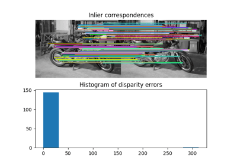

[Fundamental matrix estimation](https://scikit-image.org/docs/0.25.x/auto_examples/transform/plot_fundamental_matrix.html#sphx-glr-auto-examples-transform-plot-fundamental-matrix-py)

Fundamental matrix estimation

**`estimate(src, dst)` [[source]](https://github.com/scikit-image/scikit-image/blob/v0.25.0/skimage/transform/_geometric.py#L407-L438)**

Estimate fundamental matrix using 8-point algorithm.

The 8-point algorithm requires at least 8 corresponding point pairs for a well-conditioned solution, otherwise the over-determined solution is estimated.

**Parameters:**

**`src(N, 2) array_like`**

Source coordinates.

**`dst(N, 2) array_like`**

Destination coordinates.

**Returns:**

**`successbool`**

True, if model estimation succeeds.

**`property inverse`**

Return a transform object representing the inverse.

See Hartley & Zisserman, Ch. 8: Epipolar Geometry and the Fundamental Matrix, for an explanation of why F.T gives the inverse.

**`residuals(src, dst)` [[source]](https://github.com/scikit-image/scikit-image/blob/v0.25.0/skimage/transform/_geometric.py#L440-L468)**

Compute the Sampson distance.

The Sampson distance is the first approximation to the geometric error.

**Parameters:**

**`src(N, 2) array`**

Source coordinates.

**`dst(N, 2) array`**

Destination coordinates.

**Returns:**

**`residuals(N,) array`**

Sampson distance.

**`class skimage.transform.PiecewiseAffineTransform` [[source]](https://github.com/scikit-image/scikit-image/blob/v0.25.0/skimage/transform/_geometric.py#L1083-L1195)**

Bases: `_GeometricTransform`

Piecewise affine transformation.

Control points are used to define the mapping. The transform is based on a Delaunay triangulation of the points to form a mesh. Each triangle is used to find a local affine transform.

**Attributes:**

**`affineslist of AffineTransform objects`**

Affine transformations for each triangle in the mesh.

**`inverse_affineslist of AffineTransform objects`**

Inverse affine transformations for each triangle in the mesh.

**`__init__()` [[source]](https://github.com/scikit-image/scikit-image/blob/v0.25.0/skimage/transform/_geometric.py#L1099-L1103)**

[figure not shown]

[Piecewise Affine Transformation](https://scikit-image.org/docs/0.25.x/auto_examples/transform/plot_piecewise_affine.html#sphx-glr-auto-examples-transform-plot-piecewise-affine-py)

Piecewise Affine Transformation

**`estimate(src, dst)` [[source]](https://github.com/scikit-image/scikit-image/blob/v0.25.0/skimage/transform/_geometric.py#L1105-L1150)**

Estimate the transformation from a set of corresponding points.

Number of source and destination coordinates must match.

**Parameters:**

**`src(N, D) array_like`**

Source coordinates.

**`dst(N, D) array_like`**

Destination coordinates.

**Returns:**

**`successbool`**

True, if all pieces of the model are successfully estimated.

**`property inverse`**

Return a transform object representing the inverse.

**`residuals(src, dst)` [[source]](https://github.com/scikit-image/scikit-image/blob/v0.25.0/skimage/transform/_geometric.py#L206-L225)**

Determine residuals of transformed destination coordinates.

For each transformed source coordinate the Euclidean distance to the respective destination coordinate is determined.

**Parameters:**

**`src(N, 2) array`**

Source coordinates.

**`dst(N, 2) array`**

Destination coordinates.

**Returns:**

**`residuals(N,) array`**

Residual for coordinate.

**`class skimage.transform.PolynomialTransform(params=None, *, dimensionality=2)` [[source]](https://github.com/scikit-image/scikit-image/blob/v0.25.0/skimage/transform/_geometric.py#L1497-L1669)**

Bases: `_GeometricTransform`

2D polynomial transformation.

Has the following form:

```
X = sum[j=0:order]( sum[i=0:j]( a_ji * x**(j - i) * y**i ))
Y = sum[j=0:order]( sum[i=0:j]( b_ji * x**(j - i) * y**i ))
```

**Parameters:**

**`params(2, N) array_like, optional`**

Polynomial coefficients where `N * 2 = (order + 1) * (order + 2)`. So, a_ji is defined in `params[0, :]` and b_ji in `params[1, :]`.

**Attributes:**

**`params(2, N) array`**

Polynomial coefficients where `N * 2 = (order + 1) * (order + 2)`. So, a_ji is defined in `params[0, :]` and b_ji in `params[1, :]`.

**`__init__(params=None, *, dimensionality=2)` [[source]](https://github.com/scikit-image/scikit-image/blob/v0.25.0/skimage/transform/_geometric.py#L1519-L1531)**

**`estimate(src, dst, order=2, weights=None)` [[source]](https://github.com/scikit-image/scikit-image/blob/v0.25.0/skimage/transform/_geometric.py#L1533-L1629)**

Estimate the transformation from a set of corresponding points.

You can determine the over-, well- and under-determined parameters with the total least-squares method.

Number of source and destination coordinates must match.

The transformation is defined as:

```
X = sum[j=0:order]( sum[i=0:j]( a_ji * x**(j - i) * y**i ))
Y = sum[j=0:order]( sum[i=0:j]( b_ji * x**(j - i) * y**i ))
```

These equations can be transformed to the following form:

```
0 = sum[j=0:order]( sum[i=0:j]( a_ji * x**(j - i) * y**i )) - X
0 = sum[j=0:order]( sum[i=0:j]( b_ji * x**(j - i) * y**i )) - Y
```

which exist for each set of corresponding points, so we have a set of N * 2 equations. The coefficients appear linearly so we can write A x = 0, where:

```
A   = [[1 x y x**2 x*y y**2 ... 0 ...             0 -X]
       [0 ...                 0 1 x y x**2 x*y y**2 -Y]
        ...
        ...
      ]
x.T = [a00 a10 a11 a20 a21 a22 ... ann
       b00 b10 b11 b20 b21 b22 ... bnn c3]
```

In case of total least-squares the solution of this homogeneous system of equations is the right singular vector of A which corresponds to the smallest singular value normed by the coefficient c3.

Weights can be applied to each pair of corresponding points to indicate, particularly in an overdetermined system, if point pairs have higher or lower confidence or uncertainties associated with them. From the matrix treatment of least squares problems, these weight values are normalised, square-rooted, then built into a diagonal matrix, by which A is multiplied.

**Parameters:**

**`src(N, 2) array_like`**

Source coordinates.

**`dst(N, 2) array_like`**

Destination coordinates.

**`orderint, optional`**

Polynomial order (number of coefficients is order + 1).

**`weights(N,) array_like, optional`**

Relative weight values for each pair of points.

**Returns:**

**`successbool`**

True, if model estimation succeeds.

**`property inverse`**

Return a transform object representing the inverse.

**`residuals(src, dst)` [[source]](https://github.com/scikit-image/scikit-image/blob/v0.25.0/skimage/transform/_geometric.py#L206-L225)**

Determine residuals of transformed destination coordinates.

For each transformed source coordinate the Euclidean distance to the respective destination coordinate is determined.

**Parameters:**

**`src(N, 2) array`**

Source coordinates.

**`dst(N, 2) array`**

Destination coordinates.

**Returns:**

**`residuals(N,) array`**

Residual for coordinate.

**`class skimage.transform.ProjectiveTransform(matrix=None, *, dimensionality=2)` [[source]](https://github.com/scikit-image/scikit-image/blob/v0.25.0/skimage/transform/_geometric.py#L618-L877)**

Bases: `_GeometricTransform`

Projective transformation.

Apply a projective transformation (homography) on coordinates.

For each homogeneous coordinate $\mathbf{x} = [x, y, 1]^T$, its target position is calculated by multiplying with the given matrix, $H$, to give $H \mathbf{x}$:

```
[[a0 a1 a2]
 [b0 b1 b2]
 [c0 c1 1 ]].
```

E.g., to rotate by theta degrees clockwise, the matrix should be:

```
[[cos(theta) -sin(theta) 0]
 [sin(theta)  cos(theta) 0]
 [0            0         1]]
```

or, to translate x by 10 and y by 20:

```
[[1 0 10]
 [0 1 20]
 [0 0 1 ]].
```

**Parameters:**

**`matrix(D+1, D+1) array_like, optional`**

Homogeneous transformation matrix.

**`dimensionalityint, optional`**

The number of dimensions of the transform. This is ignored if `matrix` is not None.

**Attributes:**

**`params(D+1, D+1) array`**

Homogeneous transformation matrix.

**`__init__(matrix=None, *, dimensionality=2)` [[source]](https://github.com/scikit-image/scikit-image/blob/v0.25.0/skimage/transform/_geometric.py#L658-L668)**

[Using geometric transformations](https://scikit-image.org/docs/0.25.x/auto_examples/transform/plot_geometric.html#sphx-glr-auto-examples-transform-plot-geometric-py)

Using geometric transformations

[Types of homographies](https://scikit-image.org/docs/0.25.x/auto_examples/transform/plot_transform_types.html#sphx-glr-auto-examples-transform-plot-transform-types-py)

Types of homographies

[Robust matching using RANSAC](https://scikit-image.org/docs/0.25.x/auto_examples/transform/plot_matching.html#sphx-glr-auto-examples-transform-plot-matching-py)

Robust matching using RANSAC

[Assemble images with simple image stitching](https://scikit-image.org/docs/0.25.x/auto_examples/registration/plot_stitching.html#sphx-glr-auto-examples-registration-plot-stitching-py)

Assemble images with simple image stitching

[Corner detection](https://scikit-image.org/docs/0.25.x/auto_examples/features_detection/plot_corner.html#sphx-glr-auto-examples-features-detection-plot-corner-py)

Corner detection

[CENSURE feature detector](https://scikit-image.org/docs/0.25.x/auto_examples/features_detection/plot_censure.html#sphx-glr-auto-examples-features-detection-plot-censure-py)

CENSURE feature detector

[ORB feature detector and binary descriptor](https://scikit-image.org/docs/0.25.x/auto_examples/features_detection/plot_orb.html#sphx-glr-auto-examples-features-detection-plot-orb-py)

ORB feature detector and binary descriptor

[BRIEF binary descriptor](https://scikit-image.org/docs/0.25.x/auto_examples/features_detection/plot_brief.html#sphx-glr-auto-examples-features-detection-plot-brief-py)

BRIEF binary descriptor

[figure not shown]

[SIFT feature detector and descriptor extractor](https://scikit-image.org/docs/0.25.x/auto_examples/features_detection/plot_sift.html#sphx-glr-auto-examples-features-detection-plot-sift-py)

SIFT feature detector and descriptor extractor

**`property dimensionality`**

The dimensionality of the transformation.

**`estimate(src, dst, weights=None)` [[source]](https://github.com/scikit-image/scikit-image/blob/v0.25.0/skimage/transform/_geometric.py#L717-L839)**

Estimate the transformation from a set of corresponding points.

You can determine the over-, well- and under-determined parameters with the total least-squares method.

Number of source and destination coordinates must match.

The transformation is defined as:

```
X = (a0*x + a1*y + a2) / (c0*x + c1*y + 1)
Y = (b0*x + b1*y + b2) / (c0*x + c1*y + 1)
```

These equations can be transformed to the following form:

```
0 = a0*x + a1*y + a2 - c0*x*X - c1*y*X - X
0 = b0*x + b1*y + b2 - c0*x*Y - c1*y*Y - Y
```

which exist for each set of corresponding points, so we have a set of N * 2 equations. The coefficients appear linearly so we can write A x = 0, where:

```
A   = [[x y 1 0 0 0 -x*X -y*X -X]
       [0 0 0 x y 1 -x*Y -y*Y -Y]
        ...
        ...
      ]
x.T = [a0 a1 a2 b0 b1 b2 c0 c1 c3]
```

In case of total least-squares the solution of this homogeneous system of equations is the right singular vector of A which corresponds to the smallest singular value normed by the coefficient c3.

Weights can be applied to each pair of corresponding points to indicate, particularly in an overdetermined system, if point pairs have higher or lower confidence or uncertainties associated with them. From the matrix treatment of least squares problems, these weight values are normalised, square-rooted, then built into a diagonal matrix, by which A is multiplied.

In case of the affine transformation the coefficients c0 and c1 are 0. Thus the system of equations is:

```
A   = [[x y 1 0 0 0 -X]
       [0 0 0 x y 1 -Y]
        ...
        ...
      ]
x.T = [a0 a1 a2 b0 b1 b2 c3]
```

**Parameters:**

**`src(N, 2) array_like`**

Source coordinates.

**`dst(N, 2) array_like`**

Destination coordinates.

**`weights(N,) array_like, optional`**

Relative weight values for each pair of points.

**Returns:**

**`successbool`**

True, if model estimation succeeds.

**`property inverse`**

Return a transform object representing the inverse.

**`residuals(src, dst)` [[source]](https://github.com/scikit-image/scikit-image/blob/v0.25.0/skimage/transform/_geometric.py#L206-L225)**

Determine residuals of transformed destination coordinates.

For each transformed source coordinate the Euclidean distance to the respective destination coordinate is determined.

**Parameters:**

**`src(N, 2) array`**

Source coordinates.

**`dst(N, 2) array`**

Destination coordinates.

**Returns:**

**`residuals(N,) array`**

Residual for coordinate.

**`class skimage.transform.SimilarityTransform(matrix=None, scale=None, rotation=None, translation=None, *, dimensionality=2)` [[source]](https://github.com/scikit-image/scikit-image/blob/v0.25.0/skimage/transform/_geometric.py#L1369-L1494)**

Bases: `EuclideanTransform`

Similarity transformation.

Has the following form in 2D:

```
X = a0 * x - b0 * y + a1 =
  = s * x * cos(rotation) - s * y * sin(rotation) + a1

Y = b0 * x + a0 * y + b1 =
  = s * x * sin(rotation) + s * y * cos(rotation) + b1
```

where `s` is a scale factor and the homogeneous transformation matrix is:

```
[[a0 -b0  a1]
 [b0  a0  b1]
 [0   0   1 ]]
```

The similarity transformation extends the Euclidean transformation with a single scaling factor in addition to the rotation and translation parameters.

**Parameters:**

**`matrix(dim+1, dim+1) array_like, optional`**

Homogeneous transformation matrix.

**`scalefloat, optional`**

Scale factor. Implemented only for 2D and 3D.

**`rotationfloat, optional`**

Rotation angle, clockwise, as radians. Implemented only for 2D and 3D. For 3D, this is given in ZYX Euler angles.

**`translation(dim,) array_like, optional`**

x, y[, z] translation parameters. Implemented only for 2D and 3D.

**Attributes:**

**`params(dim+1, dim+1) array`**

Homogeneous transformation matrix.

**`__init__(matrix=None, scale=None, rotation=None, translation=None, *, dimensionality=2)` [[source]](https://github.com/scikit-image/scikit-image/blob/v0.25.0/skimage/transform/_geometric.py#L1410-L1457)**

[Using geometric transformations](https://scikit-image.org/docs/0.25.x/auto_examples/transform/plot_geometric.html#sphx-glr-auto-examples-transform-plot-geometric-py)

Using geometric transformations

[Types of homographies](https://scikit-image.org/docs/0.25.x/auto_examples/transform/plot_transform_types.html#sphx-glr-auto-examples-transform-plot-transform-types-py)

Types of homographies

**`property dimensionality`**

The dimensionality of the transformation.

**`estimate(src, dst)` [[source]](https://github.com/scikit-image/scikit-image/blob/v0.25.0/skimage/transform/_geometric.py#L1459-L1484)**

Estimate the transformation from a set of corresponding points.

You can determine the over-, well- and under-determined parameters with the total least-squares method.

Number of source and destination coordinates must match.

**Parameters:**

**`src(N, 2) array_like`**

Source coordinates.

**`dst(N, 2) array_like`**

Destination coordinates.

**Returns:**

**`successbool`**

True, if model estimation succeeds.

**`property inverse`**

Return a transform object representing the inverse.

**`residuals(src, dst)` [[source]](https://github.com/scikit-image/scikit-image/blob/v0.25.0/skimage/transform/_geometric.py#L206-L225)**

Determine residuals of transformed destination coordinates.

For each transformed source coordinate the Euclidean distance to the respective destination coordinate is determined.

**Parameters:**

**`src(N, 2) array`**

Source coordinates.

**`dst(N, 2) array`**

Destination coordinates.

**Returns:**

**`residuals(N,) array`**

Residual for coordinate.

**`property rotation`**

**`property scale`**

**`property translation`**

**`class skimage.transform.ThinPlateSplineTransform` [[source]](https://github.com/scikit-image/scikit-image/blob/v0.25.0/skimage/transform/_thin_plate_splines.py#L7-L188)**

Bases: [`object`](https://docs.python.org/3/library/functions.html#object)

Thin-plate spline transformation.

Given two matching sets of points, source and destination, this class estimates the thin-plate spline (TPS) transformation which transforms each point in source into its destination counterpart.

**Attributes:**

**`src(N, 2) array_like`**

Coordinates of control points in source image.

#### References

[1]

Bookstein, Fred L. “Principal warps: Thin-plate splines and the decomposition of deformations,” IEEE Transactions on pattern analysis and machine intelligence 11.6 (1989): 567–585. DOI:`10.1109/34.24792` https://user.engineering.uiowa.edu/~aip/papers/bookstein-89.pdf

#### Examples

```
>>> import skimage as ski
```

Define source and destination control points such that they simulate rotating by 90 degrees and generate a meshgrid from them:

```
>>> src = np.array([[0, 0], [0, 5], [5, 5], [5, 0]])
>>> dst = np.array([[5, 0], [0, 0], [0, 5], [5, 5]])
```

Estimate the transformation:

```
>>> tps = ski.transform.ThinPlateSplineTransform()
>>> tps.estimate(src, dst)
True
```

Appyling the transformation to `src` approximates `dst`:

```
>>> np.round(tps(src))
array([[5., 0.],
       [0., 0.],
       [0., 5.],
       [5., 5.]])
```

Create a meshgrid to apply the transformation to:

```
>>> grid = np.meshgrid(np.arange(5), np.arange(5))
>>> grid[1]
array([[0, 0, 0, 0, 0],
       [1, 1, 1, 1, 1],
       [2, 2, 2, 2, 2],
       [3, 3, 3, 3, 3],
       [4, 4, 4, 4, 4]])
```

```
>>> coords = np.vstack([grid[0].ravel(), grid[1].ravel()]).T
>>> transformed = tps(coords)
>>> np.round(transformed[:, 1]).reshape(5, 5).astype(int)
array([[0, 1, 2, 3, 4],
       [0, 1, 2, 3, 4],
       [0, 1, 2, 3, 4],
       [0, 1, 2, 3, 4],
       [0, 1, 2, 3, 4]])
```

**`__init__()` [[source]](https://github.com/scikit-image/scikit-image/blob/v0.25.0/skimage/transform/_thin_plate_splines.py#L71-L74)**

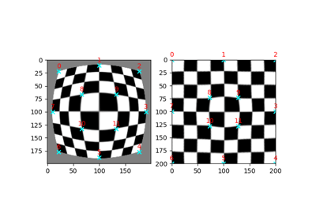

[Use thin-plate splines for image warping](https://scikit-image.org/docs/0.25.x/auto_examples/transform/plot_tps_deformation.html#sphx-glr-auto-examples-transform-plot-tps-deformation-py)

Use thin-plate splines for image warping

**`estimate(src, dst)` [[source]](https://github.com/scikit-image/scikit-image/blob/v0.25.0/skimage/transform/_thin_plate_splines.py#L110-L155)**

Estimate optimal spline mappings between source and destination points.

**Parameters:**

**`src(N, 2) array_like`**

Control points at source coordinates.

**`dst(N, 2) array_like`**

Control points at destination coordinates.

**Returns:**

**success: bool**

True indicates that the estimation was successful.

#### Notes

The number N of source and destination points must match.

**`property inverse`**